# MEML_HW08_Soln

**Machine Learning for Mechanical Engineering**  
**Homework 08**  
**Due Tuesday, 06/02/2020, 09:30 AM**

TA: Taewan Kim  
Instructor: Prof. Seungchul Lee  
http://iai.postech.ac.kr/  
Industrial AI Lab at POSTECH

- For your handwritten solution, scan or take a picture of them.
- For your code, only .ipynb file will be graded.
  - Please write your NAME and student ID on your .ipynb files. ex) KimTaewan_HW08.ipynb
- Please compress all files to make a single .zip file
  - Please write your NAME and student ID on your .zip files. ex) KimTaewan_HW08.zip
  - Submit it to LMS
- Do not submit a printed version of your code. It will not be graded.

# Problem 1

There are data points from four classes in 2 dimensional space. Each data point has its own centroid.

1) Plot the data points on 2-d plane and calculate the centroid of each class

```python
import numpy as np
import matplotlib.pyplot as plt
```

```python
data1 = np.array((np.random.normal(0, 0.2, 100), np.random.normal(0.0, 0.2, 100)))
data2 = np.array((np.random.normal(1.2, 0.3, 100), np.random.normal(1.1, 0.3, 100)))
data3 = np.array((np.random.normal(1.6, 0.2, 100), np.random.normal(1.8, 0.4, 100)))
data4 = np.array((np.random.normal(0.3, 0.1, 100), np.random.normal(0.5, 0.3, 100)))
```

```
centroid 1 :  [-0.007650914449279847, -0.03937642506138611]
centroid 2 :  [1.210250464992801, 1.090561242495207]
centroid 3 :  [1.5977577573287152, 1.7832820754679304]
centroid 4 :  [0.3036205658640481, 0.45155725882239733]
```

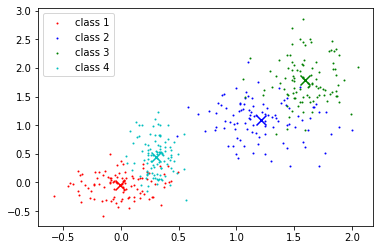

```python
# Write your code here
c1x = np.mean(data1[0])
c1y = np.mean(data1[1])
c2x = np.mean(data2[0])
c2y = np.mean(data2[1])
c3x = np.mean(data3[0])
c3y = np.mean(data3[1])
c4x = np.mean(data4[0])
c4y = np.mean(data4[1])

c1 = [c1x, c1y]
c2 = [c2x, c2y]
c3 = [c3x, c3y]
c4 = [c4x, c4y]
print('centroid 1 : ', c1)
print('centroid 2 : ', c2)
print('centroid 3 : ', c3)
print('centroid 4 : ', c4)

plt.scatter(data1[0], data1[1], label ='class 1', c = 'r', s = 1)
plt.scatter(data2[0], data2[1], label ='class 2', c = 'b', s = 1)
plt.scatter(data3[0], data3[1], label ='class 3', c = 'g', s = 1)
plt.scatter(data4[0], data4[1], label ='class 4', c = 'c', s = 1)
plt.scatter(c1[0], c1[1],marker = 'x', s = 100, c = 'r')
plt.scatter(c2[0], c2[1],marker = 'x', s = 100, c = 'b')
plt.scatter(c3[0], c3[1],marker = 'x', s = 100, c = 'g')
plt.scatter(c4[0], c4[1],marker = 'x', s = 100, c = 'c')
plt.legend()
plt.show()
```

2) Do k-means clustering on the given data points and compare the centroids of k-means clustering with 1-1) centroids. ($k = 4$)

```
centroid 1 :  [0.305367544688727, 0.5652454404700568]
centroid 2 :  [1.6030807081449816, 1.8433073701407139]
centroid 3 :  [0.0423545195249528, -0.036250602185388475]
centroid 4 :  [1.2310076308837523, 1.0716529860631114]
```

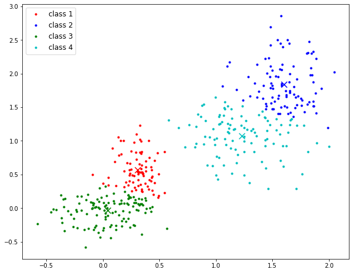

```python
# Write your code here
from sklearn.cluster import KMeans

X = np.hstack((data1, data2, data3, data4))
X = np.asmatrix(X)
X = X.T
kmeans = KMeans(n_clusters = 4, random_state = 0)
kmeans.fit(X)


c1x = np.mean(X[kmeans.labels_ == 0,0])
c1y = np.mean(X[kmeans.labels_ == 0,1])
c2x = np.mean(X[kmeans.labels_ == 1,0])
c2y = np.mean(X[kmeans.labels_ == 1,1])
c3x = np.mean(X[kmeans.labels_ == 2,0])
c3y = np.mean(X[kmeans.labels_ == 2,1])
c4x = np.mean(X[kmeans.labels_ == 3,0])
c4y = np.mean(X[kmeans.labels_ == 3,1])

c1 = [c1x, c1y]
c2 = [c2x, c2y]
c3 = [c3x, c3y]
c4 = [c4x, c4y]
print('centroid 1 : ', c1)
print('centroid 2 : ', c2)
print('centroid 3 : ', c3)
print('centroid 4 : ', c4)

plt.figure(figsize = (10,8))
plt.plot(X[kmeans.labels_ == 0,0],X[kmeans.labels_ == 0,1], 'r.', label = 'class 1')
plt.plot(X[kmeans.labels_ == 1,0],X[kmeans.labels_ == 1,1], 'b.', label = 'class 2')
plt.plot(X[kmeans.labels_ == 2,0],X[kmeans.labels_ == 2,1], 'g.', label = 'class 3')
plt.plot(X[kmeans.labels_ == 3,0],X[kmeans.labels_ == 3,1], 'c.', label = 'class 4')
plt.scatter(c1[0], c1[1],marker = 'x', s = 100, c = 'r')
plt.scatter(c2[0], c2[1],marker = 'x', s = 100, c = 'b')
plt.scatter(c3[0], c3[1],marker = 'x', s = 100, c = 'g')
plt.scatter(c4[0], c4[1],marker = 'x', s = 100, c = 'c')
plt.legend(fontsize = 12)
plt.show()
```

3) Choose the number of clusters by checking the 'elbow-point' in the cost verses $k$ graph.

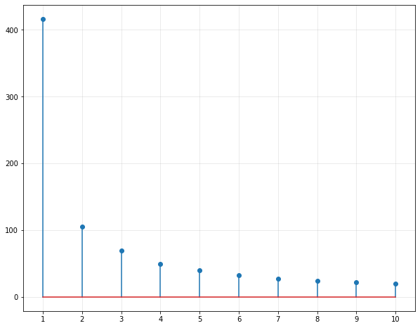

```python
# Write your code here

cost = []
for i in range(1,11):
    kmeans = KMeans(n_clusters = i, random_state = 0).fit(X)
    cost.append(abs(kmeans.score(X)))

plt.figure(figsize = (10,8))
plt.stem(range(1,11), cost)
plt.xticks(np.arange(11))
plt.xlim([0.5, 10.5])
plt.grid(alpha = 0.3)
plt.show()
```

# Problem 2

In our class, we did k-means clustering on image colors. In some special cases, we can use k-means clustering for noise reduction in color. This is one of images from Piet Mondrian.

[Download data](https://www.dropbox.com/s/18g3twjkibh1tii/Piet%20Mondrian.jpg?dl=1)

1) Do the k-means clustering on this image. (Choose appropriate $k$ that you think)

[figure not shown]

```python
img = plt.imread('./data_files/piet mondrian.jpg')
plt.axis('off')
plt.imshow(img)
```

```python
from sklearn.cluster import KMeans

m = img.shape[0]
n = img.shape[1]
X = img.reshape(m*n, 3)

k = 6
kmeans = KMeans(n_clusters = k, random_state = 0)
kmeans.fit(X)
```

```
KMeans(algorithm='auto', copy_x=True, init='k-means++', max_iter=300,
       n_clusters=6, n_init=10, n_jobs=None, precompute_distances='auto',
       random_state=0, tol=0.0001, verbose=0)
```

```python
X_clustered = np.zeros([m*n,3])

for i in range(k):
    X_clustered[np.where(kmeans.labels_ == i)] = kmeans.cluster_centers_[i]
```

[figure not shown]

```python
plt.figure(figsize = (8,8))
plt.imshow(X_clustered.reshape(m, n, 3).astype('uint8'))
plt.axis('off')
plt.show()
```

2) How many clusters are needed for this image? Check the cost as $k$ increases.

```
1
2
3
4
5
6
7
```

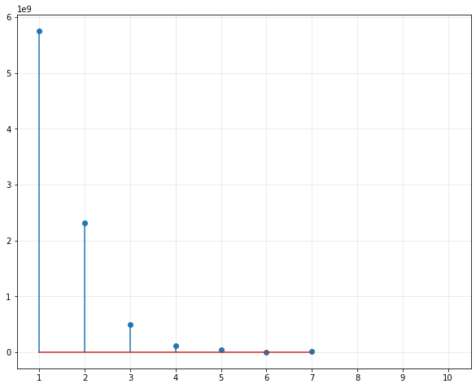

```python
# Write your code here

cost = []
for i in range(1, 8):
    kmeans = KMeans(n_clusters = i, random_state = 0).fit(X)
    cost.append(abs(kmeans.score(X_clustered)))
    print(i)

plt.figure(figsize = (10,8))
plt.stem(range(1,8), cost)
plt.xticks(np.arange(11))
plt.xlim([0.5, 10.5])
plt.grid(alpha = 0.3)
plt.show()
```

# Problem 3

In statistics, it is important to understand the characteristics of population, sample and distributions.

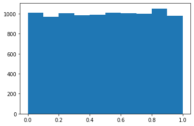

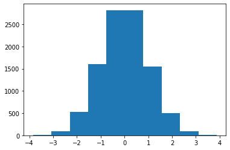

```python
## random number generation (1D)
m = 10000

uniform =  np.random.rand(m,1)
normal = np.random.randn(m,1)

plt.hist(uniform)
plt.show()
plt.hist(normal)
plt.show()
```

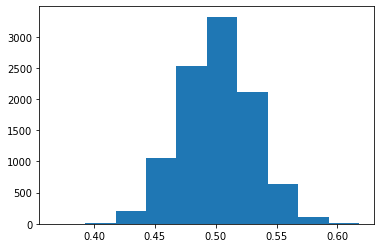

```python
# uniform distribution
n = 100
N = 10000
S = []
for i in range(N):
    index = np.random.randint(0, m, n)
    data = uniform[index]
    S.append(np.mean(data))
plt.hist(S)
```

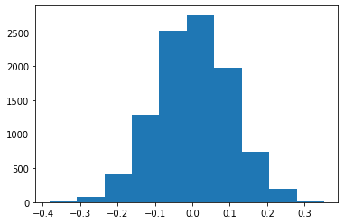

```python
# normal distribution
n = 100
N = 10000
S = []
for i in range(N):
    index = np.random.randint(0, m, n)
    data = normal[index]
    S.append(np.mean(data))
plt.hist(S)
```

3) With given data, calculate covariance, covariance matrix and correlation coefficient.

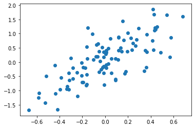

```python
x = np.random.normal(0, 0.3, 100)
data = np.array((x, 2 * x + np.random.normal(0, 0.5, 100)))
plt.scatter(data[0], data[1])
```

```python
# write your code here

cov = np.cov(data)
print(cov)
print('correlation coeff : ', cov[0,1] / np.sqrt(cov[0,0] * cov[1,1]))
```

```
[[0.08453511 0.16761457]
 [0.16761457 0.5857973 ]]
correlation coeff :  0.7532160062509794
```